## CDFA Annual Reports

### State-level data

Data presented below found in reports listed [here](https://www.cdfa.ca.gov/Statistics/).

The TOTAL VALUE variable is based on the value of quantity harvetsed for crops and the value of quantity marketed for livestock. Value for “Livestock” and “Dairy” come from a different table, where TOTAL VALUE refers to the gross value of commodities and services produced within a year. The variables AREA HARVESTED and CA SHARE were not available for “Livestock” and “Dairy,” though CA is consistently one of the top producers in these sectors.

“Dairy” includes “milk and cream.” “Alfalfa” includes “Hay, alfalfa and other.” “Cattle” includes all “meat animals.” Values for “Tomatoes” include “Tomatoes, fresh market” and “Tomatoes, processing.” Tomatoe shares of CA production in US market are for “Tomatoes, processing” since the aggregate “Tomatoes” category was not available. “Lettuce” includes “Lettuce, Romaine,” “Lettuce, Head,” and “Lettuce, Leaf.” Shares of CA production in US market for “Lettuce” is for “Lettuce, Leaf” as aggregate data was not available.

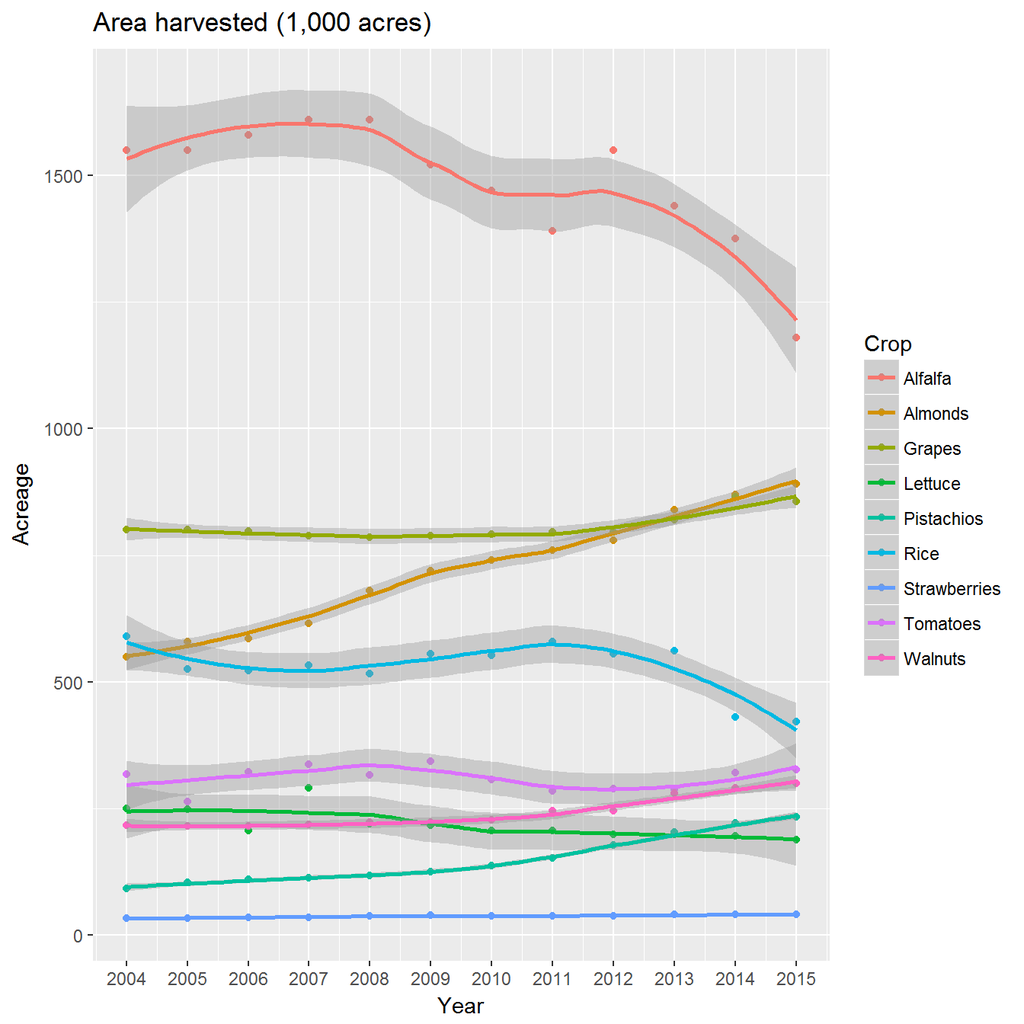

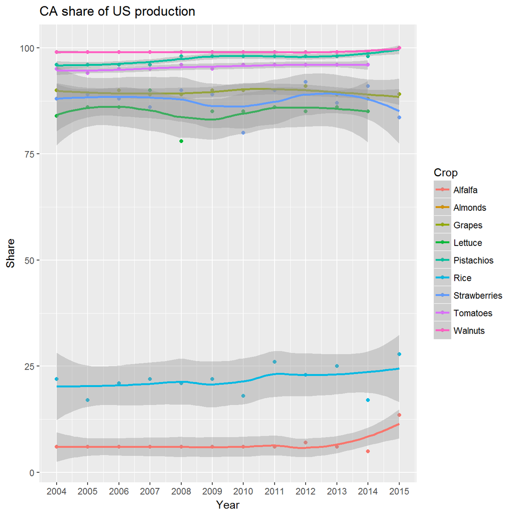

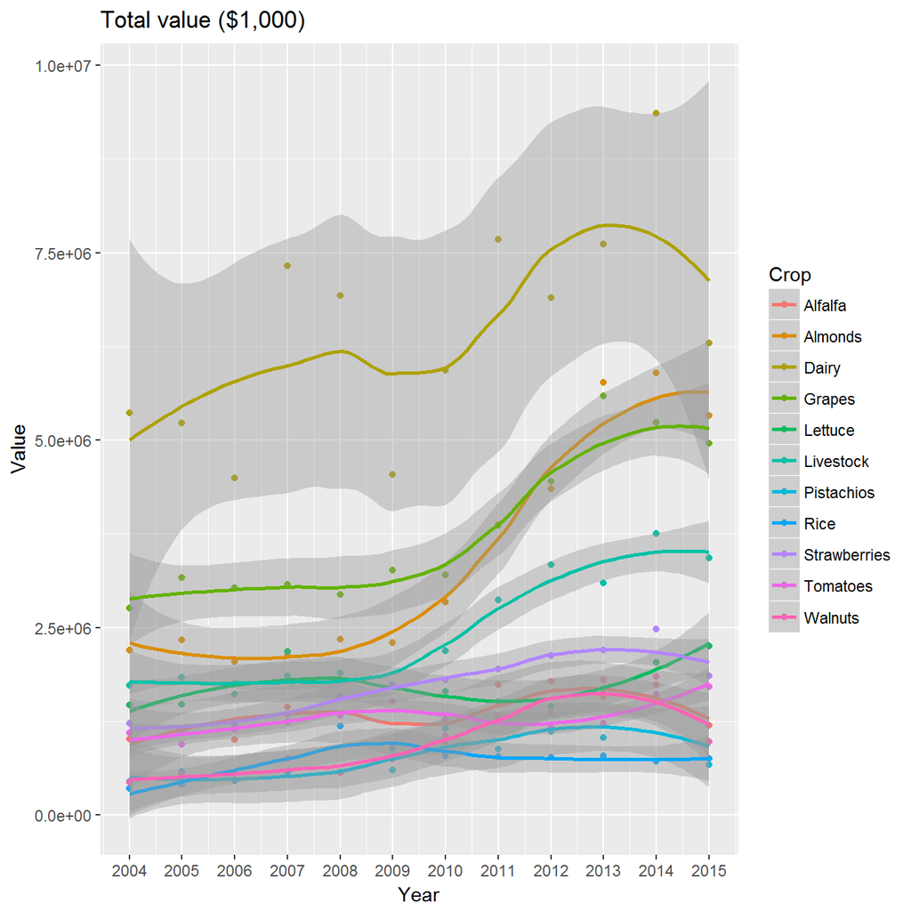

### County-level data

County-annual datasets were found [here](https://www.nass.usda.gov/Statistics_by_State/California/Publications/AgComm/Detail/). Average yields for the state of CA through time for each crop are plotted below. Note some extreme outliers, which are likely from data errors since it is fairly unreasonable to expect yields to vary that significantly across counties. In these plots, dots are counties (n=58) and the line is the Loess curve fit to the points with rows containing NAs removed from the analysis. Multiple naming conventions were used for each crop in the original NASS data (due to changes in coding system through time). To see aggregation of variables, see nass.R. This script also documents removal of outliers.

#### County-level yield

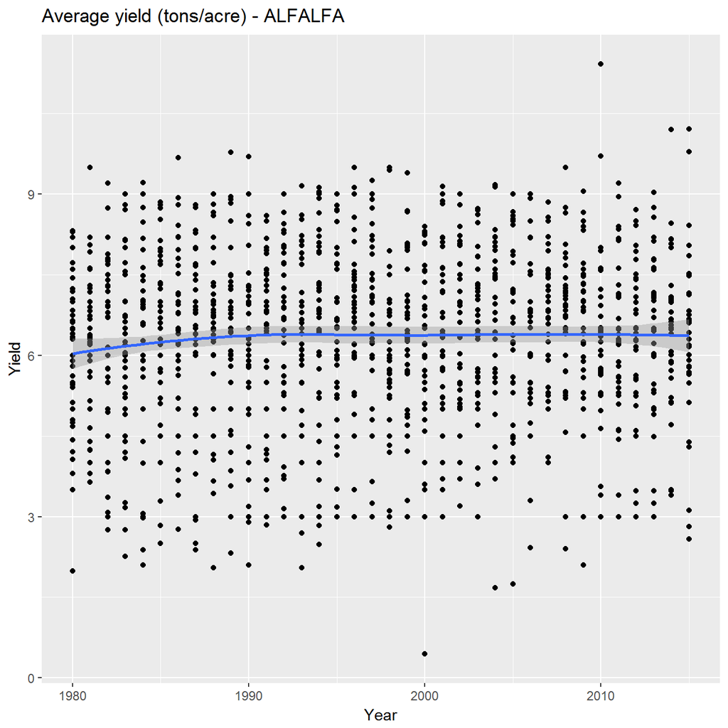

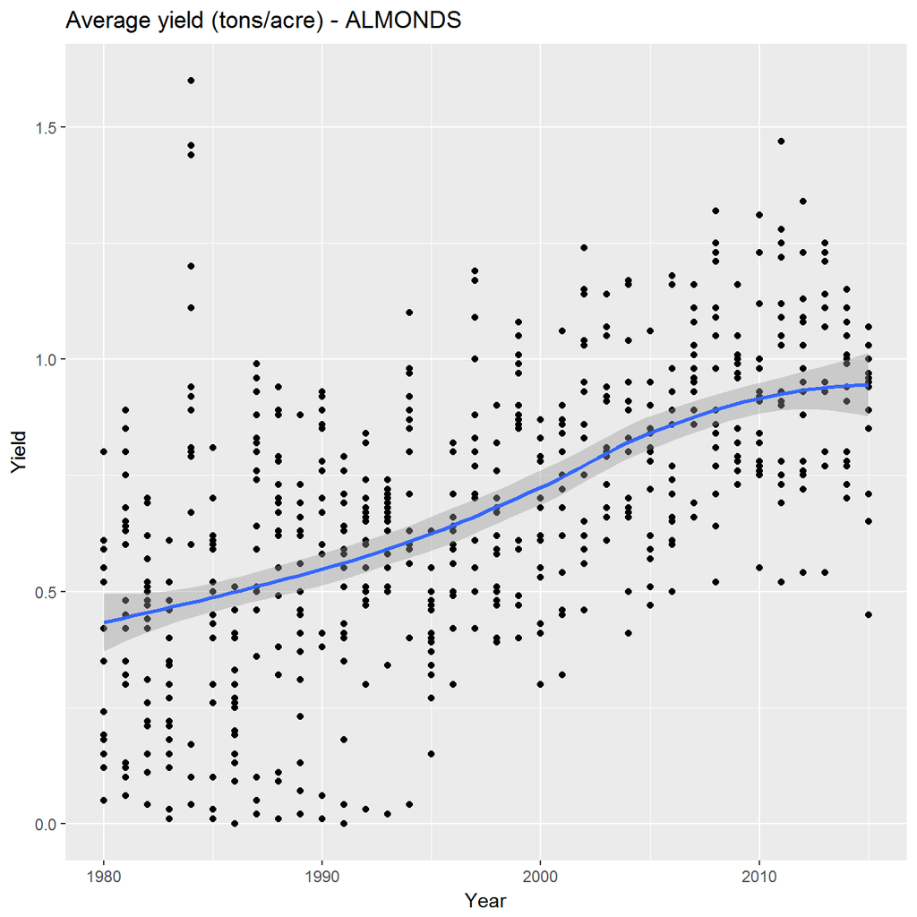

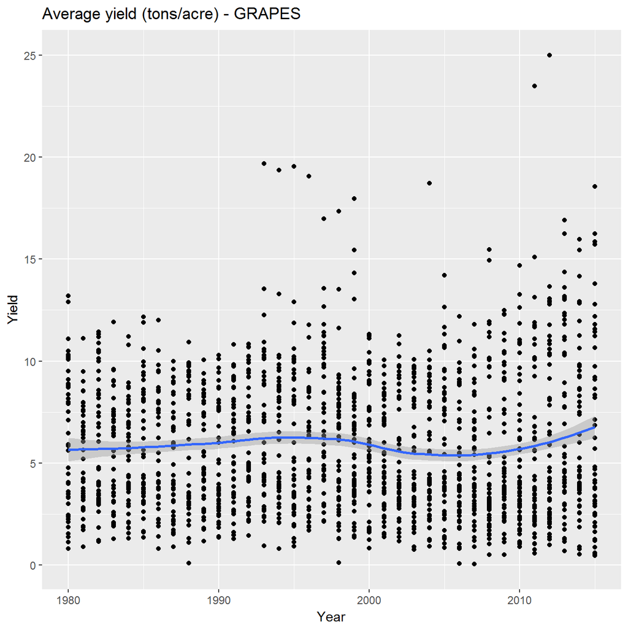

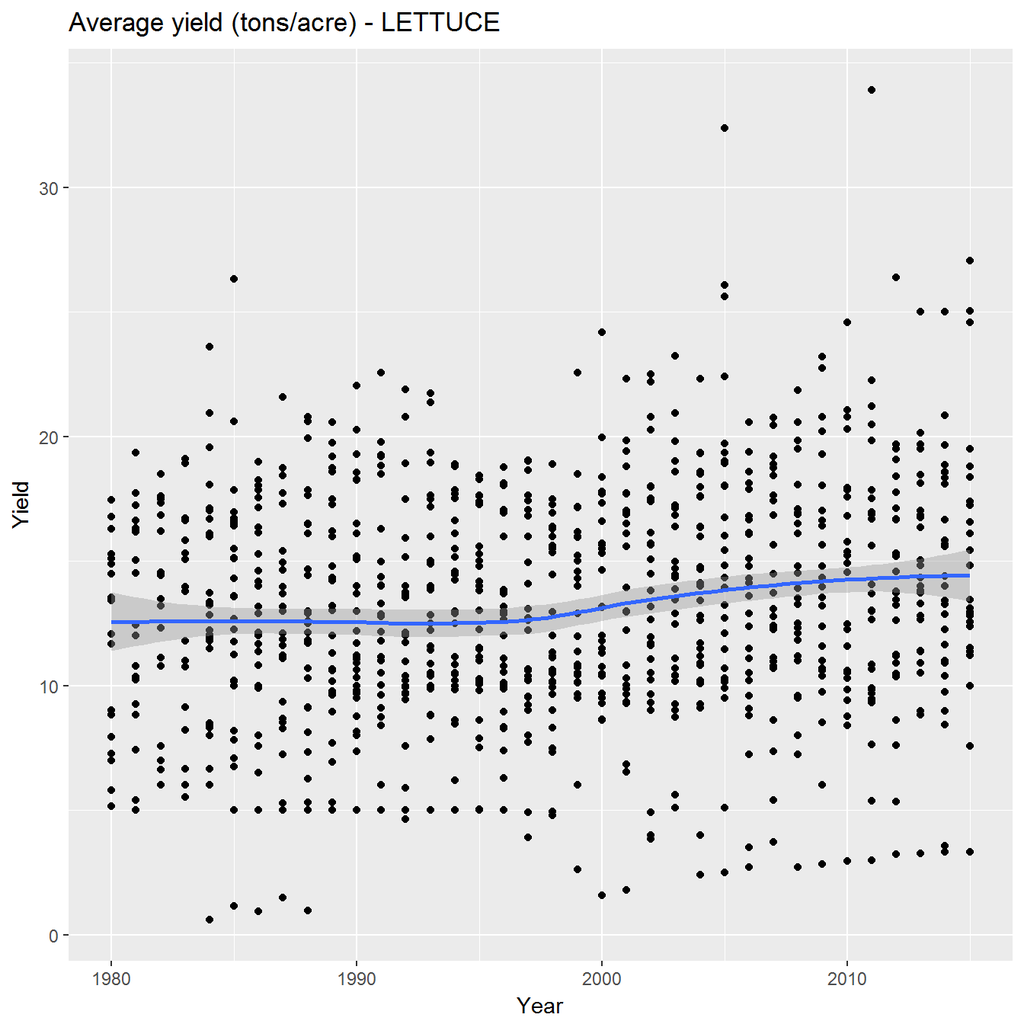

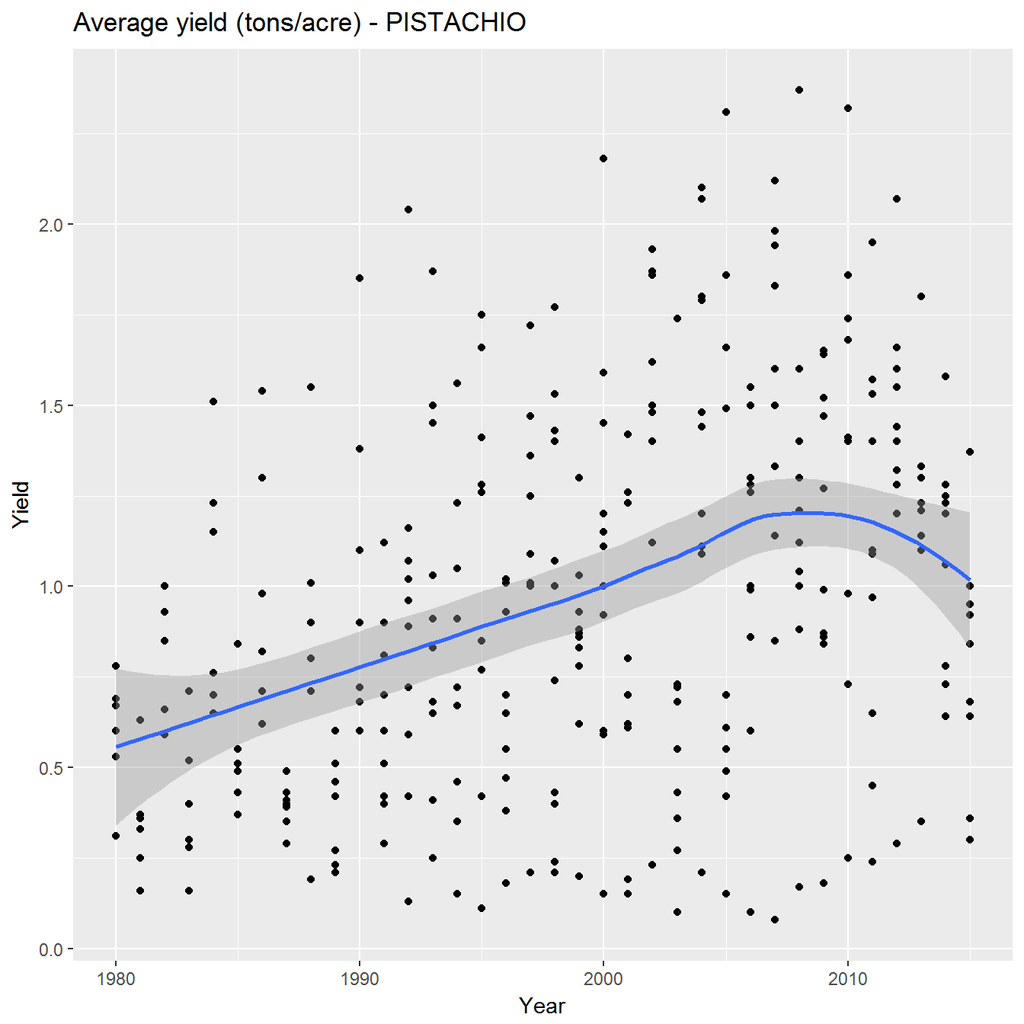

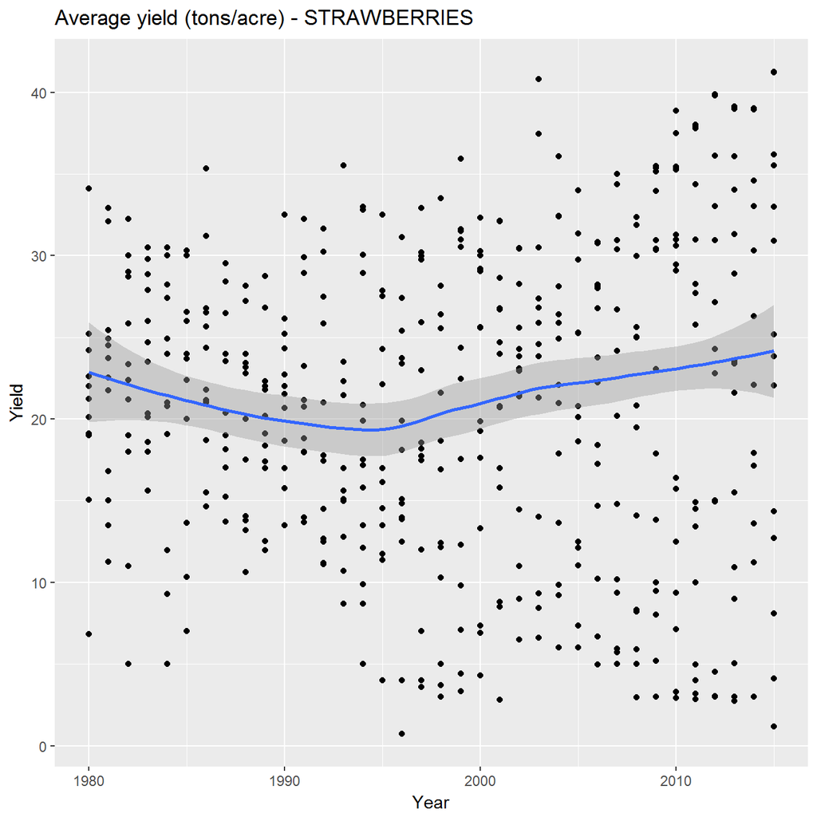

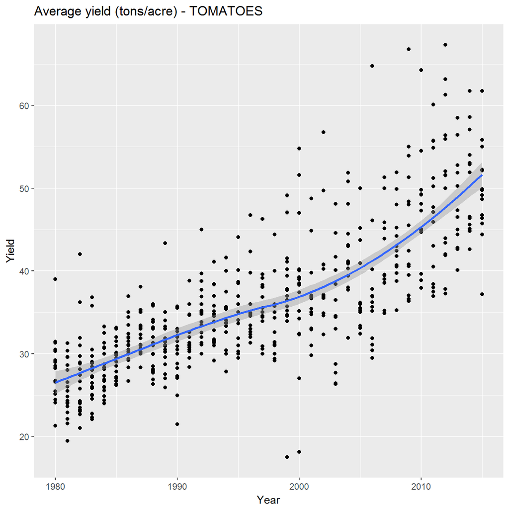

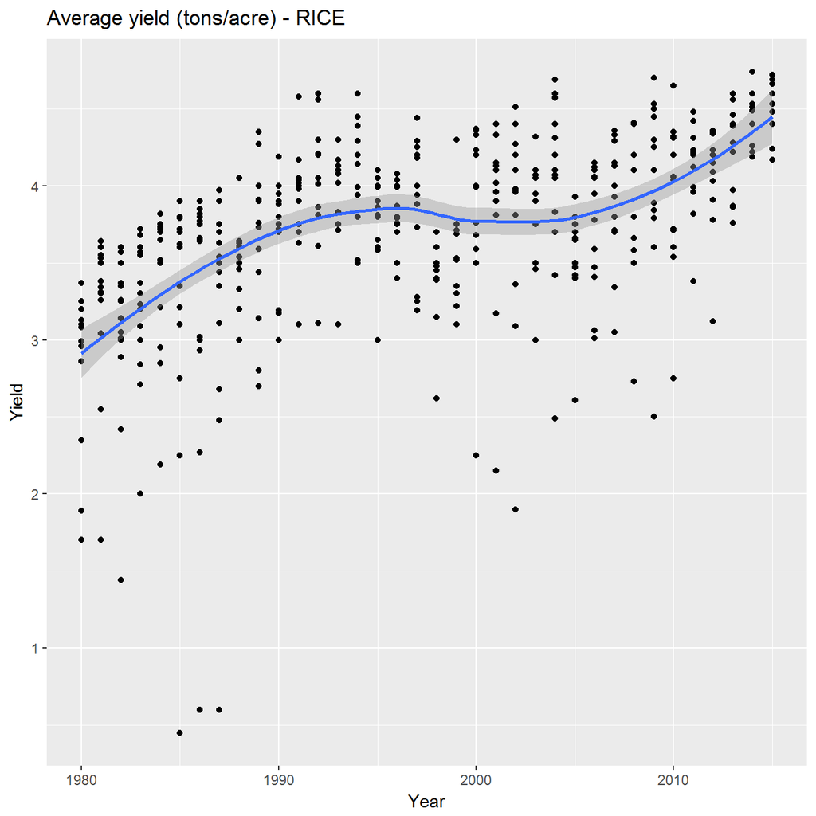

### County-level acreage

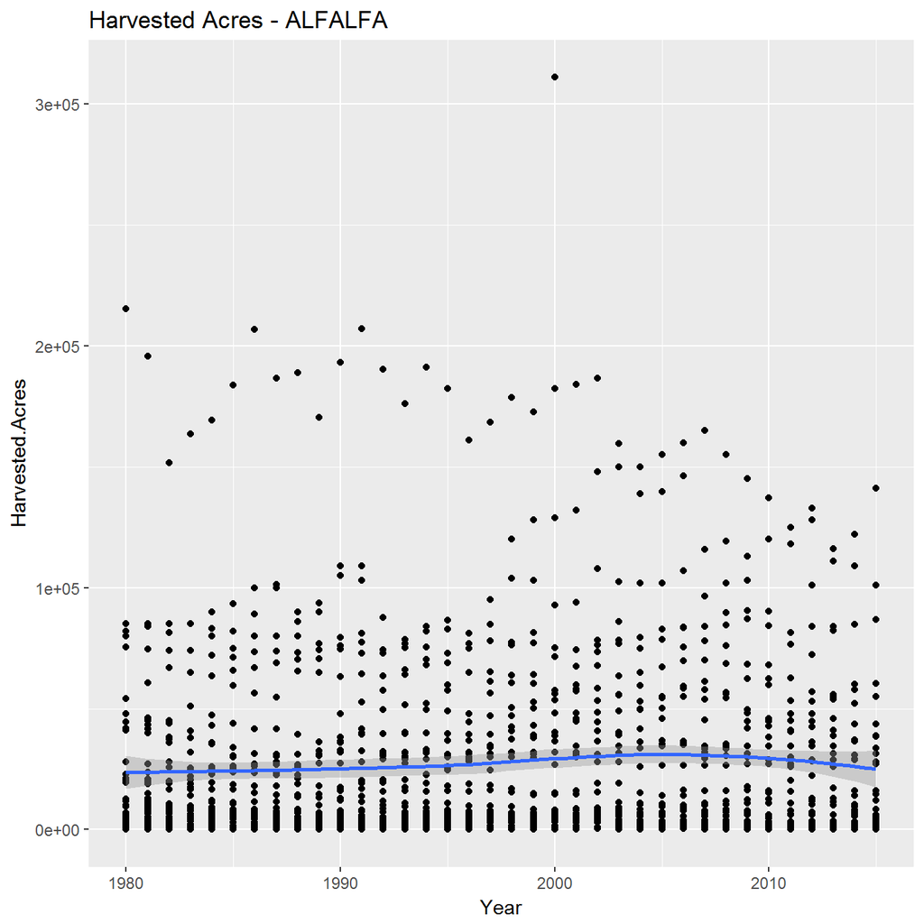

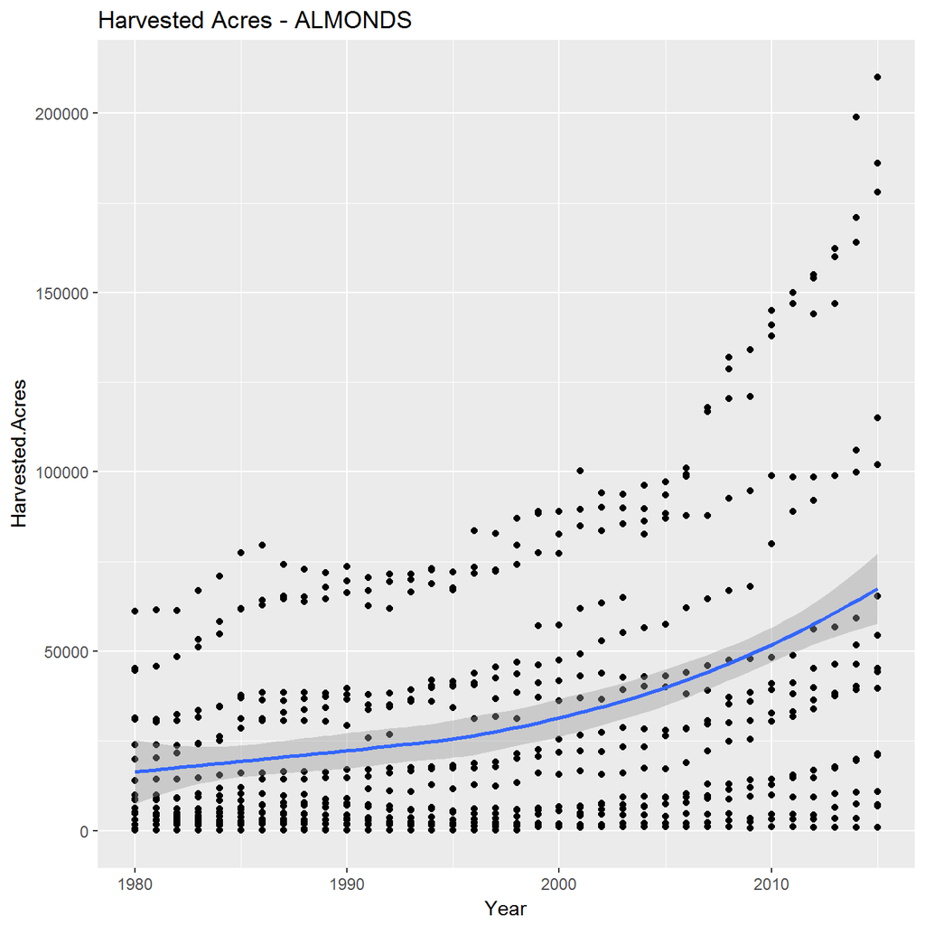

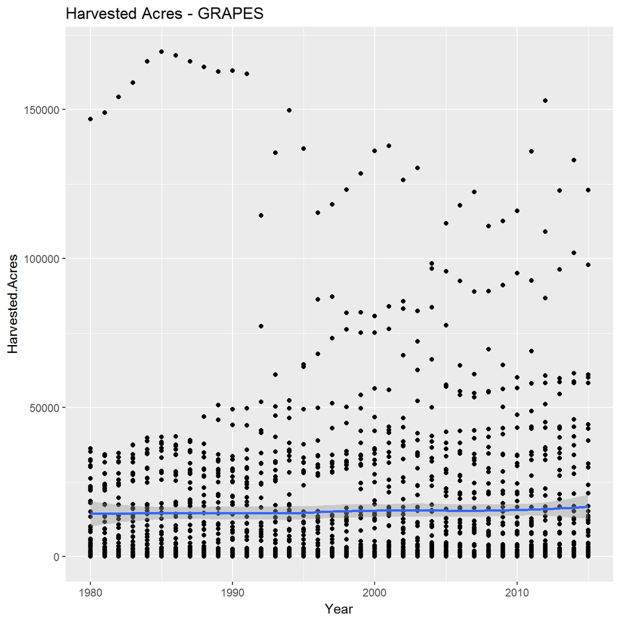

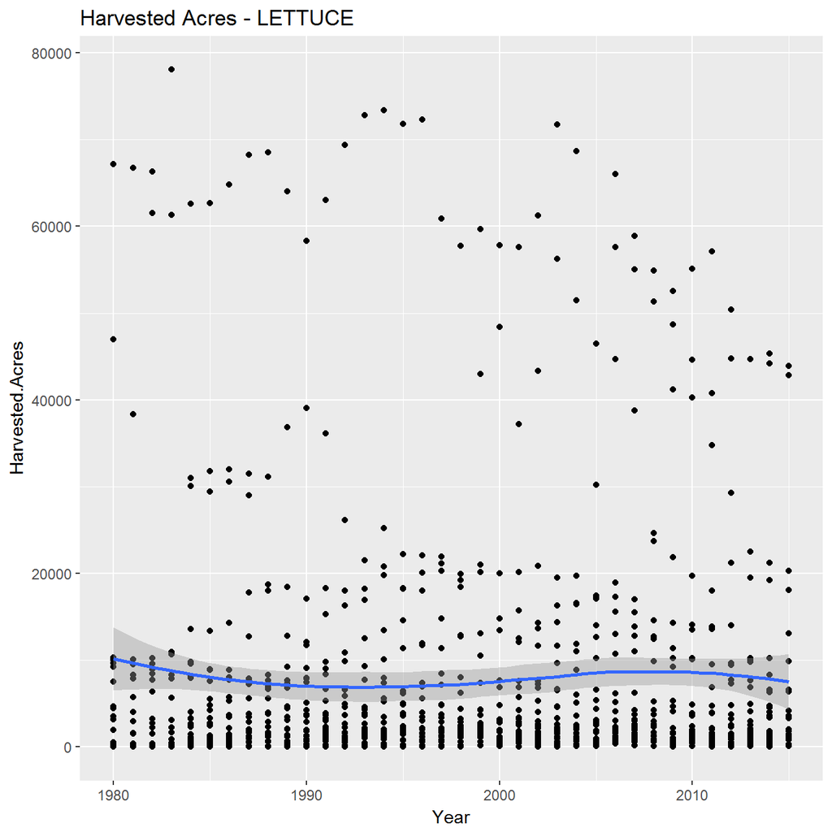

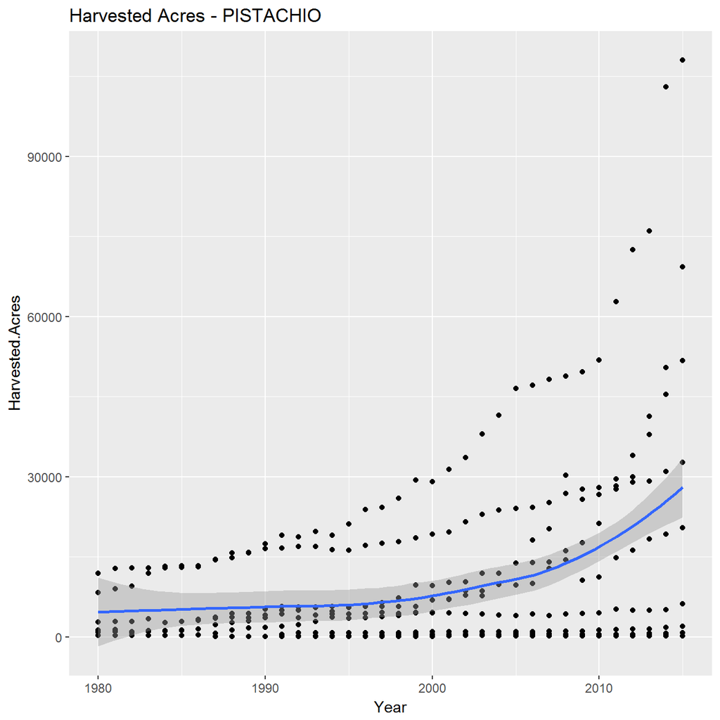

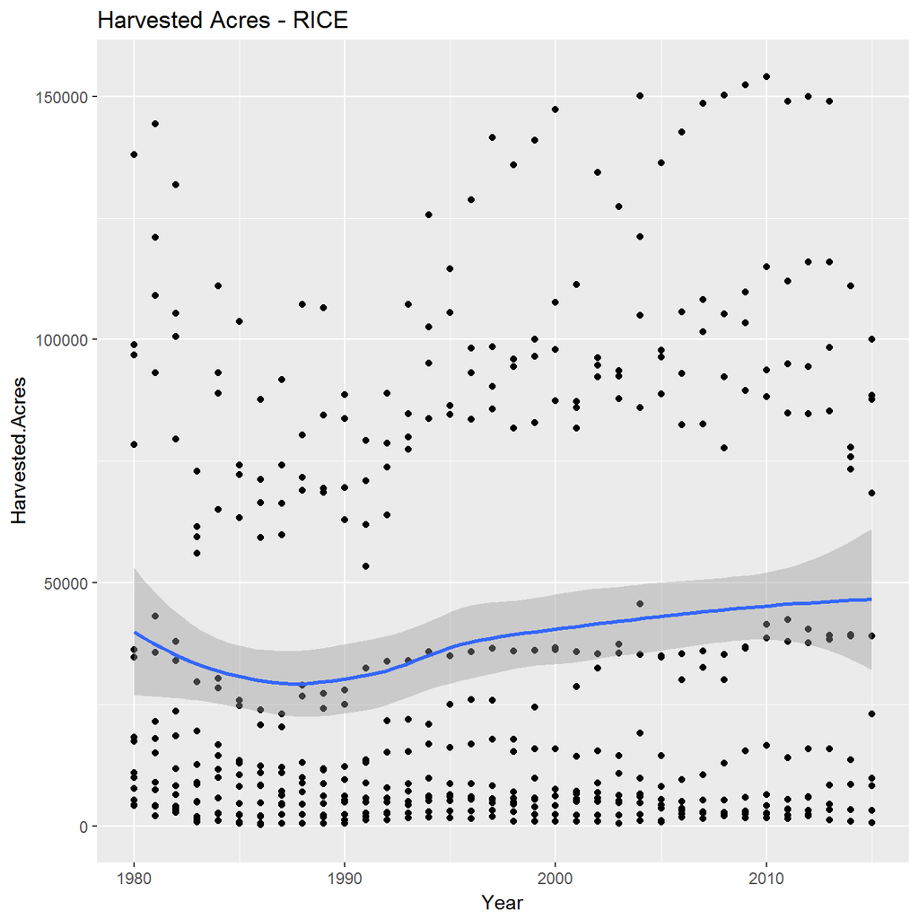

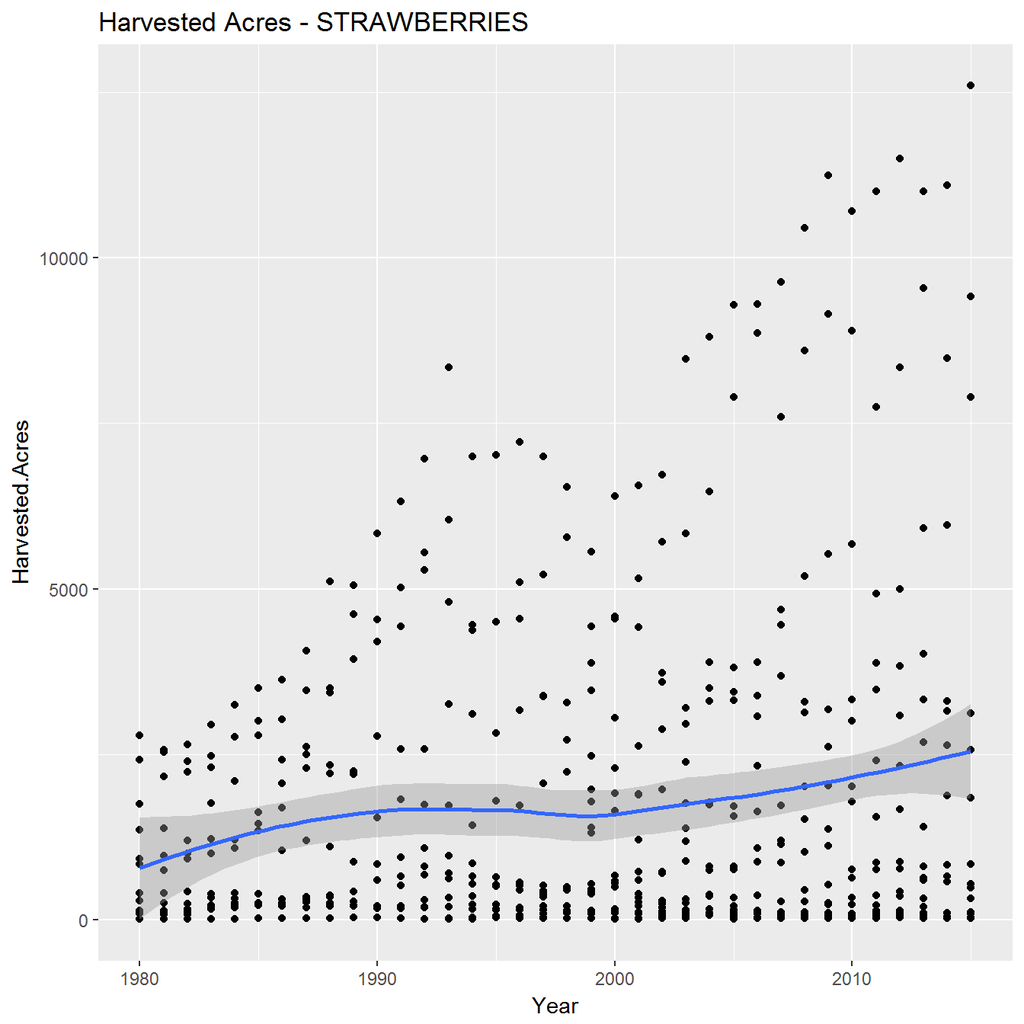

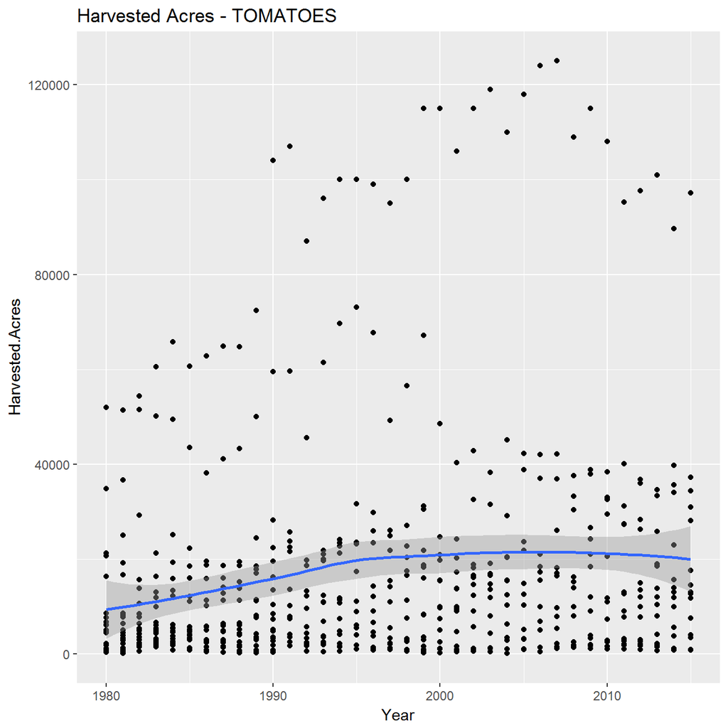

[figure not shown]

Note that for several crops (almonds, pistachios), there are strong paths in the data. These are counties with exceptionally high acreage through time.

Here’s a summary plot of all counties:

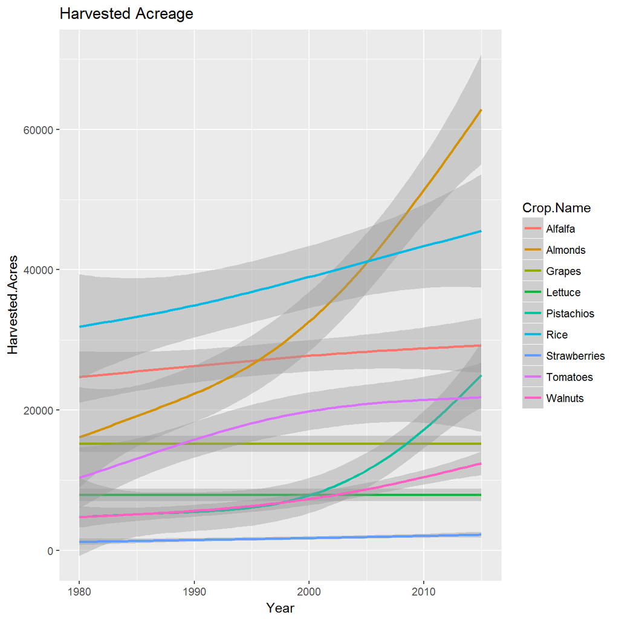

### County-level production (Tons)

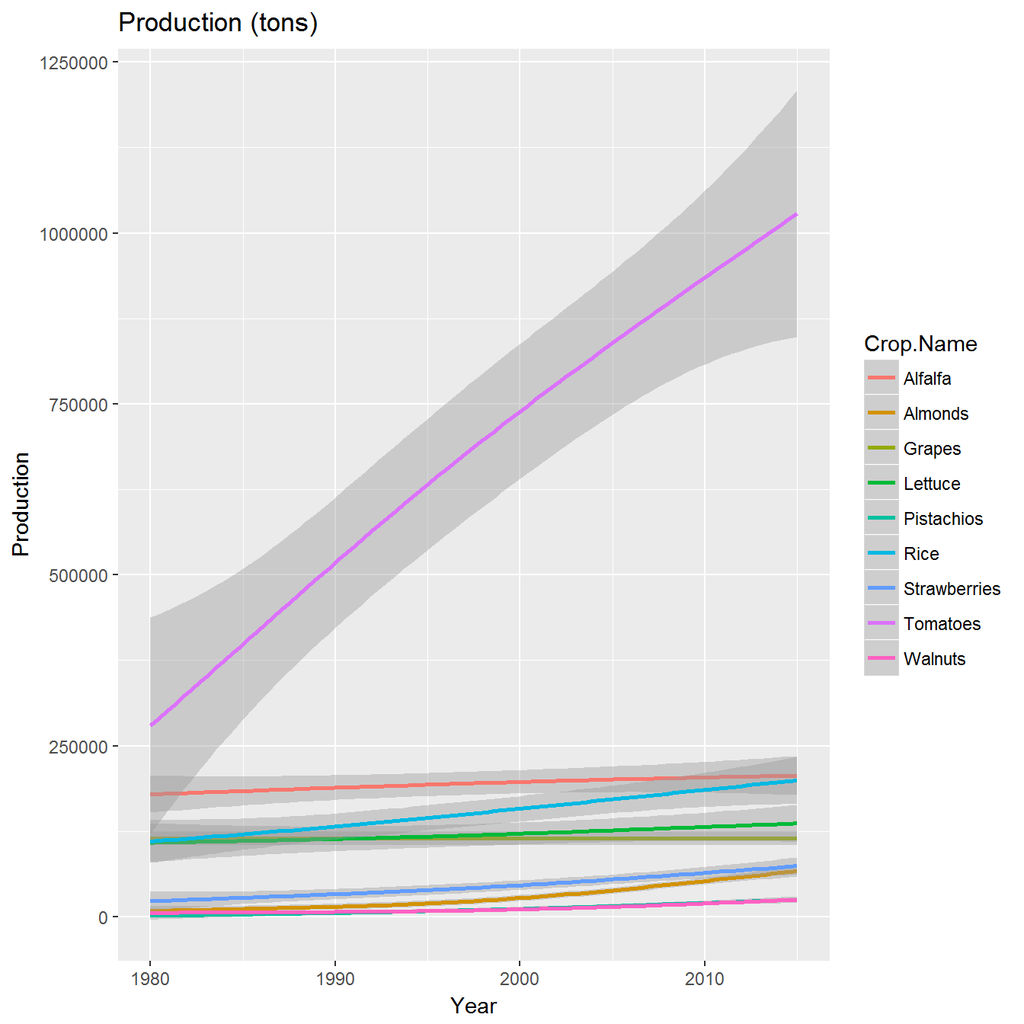

### County-level net value (USD)

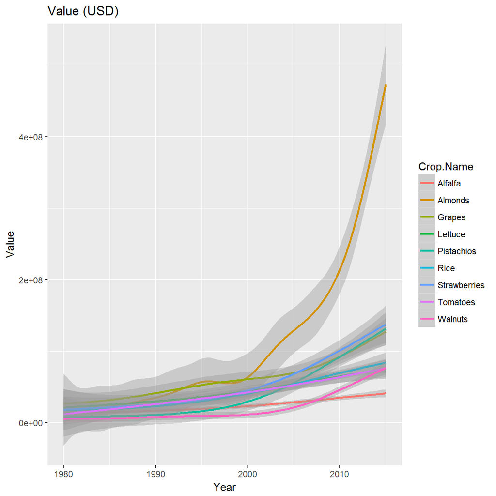

### County-level price-per unit (USD)

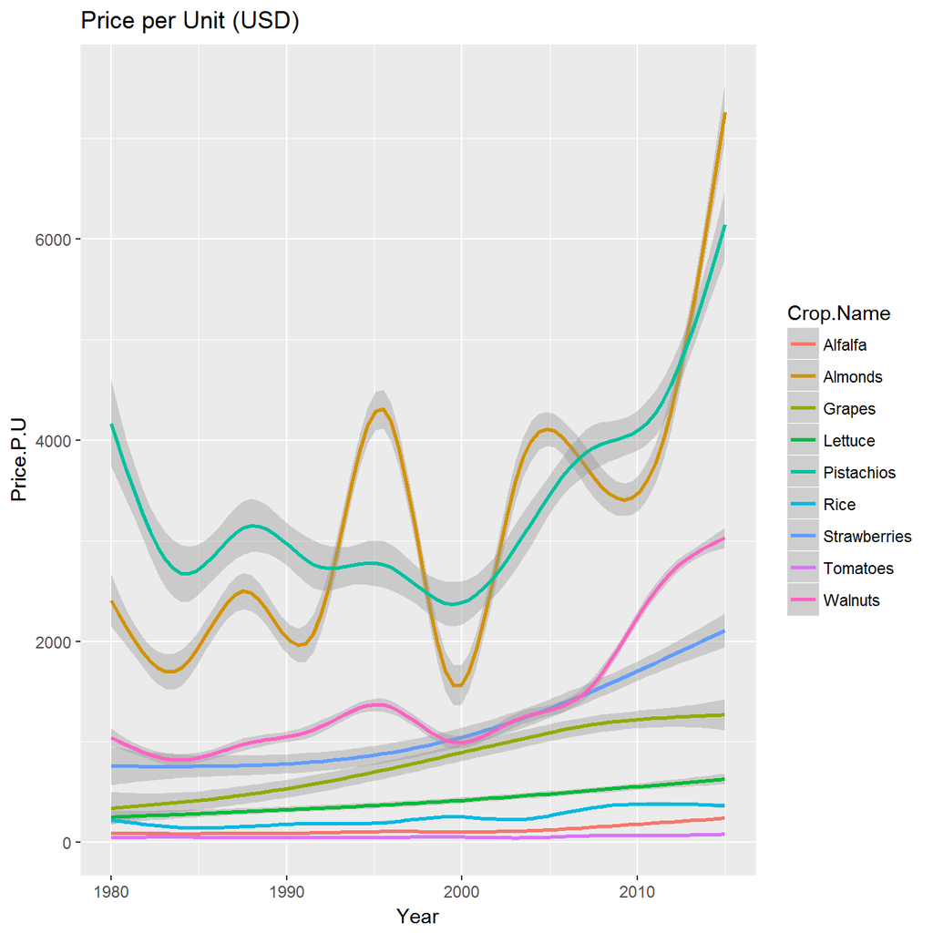